# Part I - Ford GoBike Exploratory Data Analysis

## by (Solomon 'Juwonlo Olorunleke)

- [Introduction](https://example.com)
- [Data Wrangling](https://example.com)
- [Univariate Exploration](https://example.com)
- [Bivariate Exploration](https://example.com)
- [Multivariate Exploration](https://example.com)
- [Conclusion](https://example.com)

### Introduction

> This data set includes information about individual rides made in a bike-sharing system covering the greater San Francisco Bay area. Bay Area Bike Share is a company that provides on-demand bike rentals for customers in San Francisco, Redwood City, Palo Alto, Mountain View, and San Jose. Users can unlock bikes from a variety of stations throughout each city, and return them to any station within the same city. Users pay for the service either through a yearly subscription or by purchasing 3-day or 24-hour passes. Users can make an unlimited number of trips, with trips under thirty minutes in length having no additional charge; longer trips will incur overtime fees. The source data (Ford GoBike System Data) is available at : https://s3.amazonaws.com/baywheels-data/index.html.

> Some of the features in the dataset include:
- User Type (Subscriber or Customer – “Subscriber” = Member or “Customer” = Casual)
- Trip Duration(in seconds)
- Bike ID
- Start Time and Date
- End Time and Date
- Start Station ID
- End Station ID
- Start Station Name
- End Station Name
- End Station Latitude
- End Station Longitude
- Start Station Latitude
- Start Station Longitude

## Preliminary Wrangling

```python
# import all packages and set plots to be embedded inline
import numpy as np
import pandas as pd
import matplotlib.pyplot as plt
import seaborn as sb
import zipfile
import os
from glob import glob
%matplotlib inline
```

> Extracting the individual files in the downloaded zip file in the working directory

```python
# Extract all contents from zip file
with zipfile.ZipFile('fordgobike-tripdata.zip', 'r') as myzip:
    myzip.extractall()
```

> Opening the extracted files one after the other and concatenating them together. The merged dataset is renamed and saved as Ford2019.csv

```python
files = glob(os.path.join('*.csv'))
df = pd.concat((pd.read_csv(f) for f in files), ignore_index = False)
df.to_csv('Ford2019.csv', index=False)
```

> Reading the dataset into the notebook

```python
df = pd.read_csv('Ford2019.csv')
#Checking the head of the dataset
df.head()
```

|  | duration_sec | start_time | end_time | start_station_id | start_station_name | start_station_latitude | start_station_longitude | end_station_id | end_station_name | end_station_latitude | end_station_longitude | bike_id | user_type | bike_share_for_all_trip |
| --- | --- | --- | --- | --- | --- | --- | --- | --- | --- | --- | --- | --- | --- | --- |
| 0 | 52185 | 2019-02-28 17:32:10.1450 | 2019-03-01 08:01:55.9750 | 21.0 | Montgomery St BART Station (Market St at 2nd St) | 37.789625 | -122.400811 | 13.0 | Commercial St at Montgomery St | 37.794231 | -122.402923 | 4902 | Customer | No |
| 1 | 42521 | 2019-02-28 18:53:21.7890 | 2019-03-01 06:42:03.0560 | 23.0 | The Embarcadero at Steuart St | 37.791464 | -122.391034 | 81.0 | Berry St at 4th St | 37.775880 | -122.393170 | 2535 | Customer | No |
| 2 | 61854 | 2019-02-28 12:13:13.2180 | 2019-03-01 05:24:08.1460 | 86.0 | Market St at Dolores St | 37.769305 | -122.426826 | 3.0 | Powell St BART Station (Market St at 4th St) | 37.786375 | -122.404904 | 5905 | Customer | No |
| 3 | 36490 | 2019-02-28 17:54:26.0100 | 2019-03-01 04:02:36.8420 | 375.0 | Grove St at Masonic Ave | 37.774836 | -122.446546 | 70.0 | Central Ave at Fell St | 37.773311 | -122.444293 | 6638 | Subscriber | No |
| 4 | 1585 | 2019-02-28 23:54:18.5490 | 2019-03-01 00:20:44.0740 | 7.0 | Frank H Ogawa Plaza | 37.804562 | -122.271738 | 222.0 | 10th Ave at E 15th St | 37.792714 | -122.248780 | 4898 | Subscriber | Yes |

```python
#Checking the last few rows of the dataset
df.tail()
```

|  | duration_sec | start_time | end_time | start_station_id | start_station_name | start_station_latitude | start_station_longitude | end_station_id | end_station_name | end_station_latitude | end_station_longitude | bike_id | user_type | bike_share_for_all_trip |
| --- | --- | --- | --- | --- | --- | --- | --- | --- | --- | --- | --- | --- | --- | --- |
| 870899 | 451 | 2019-03-01 00:06:16.6170 | 2019-03-01 00:13:47.9220 | 78.0 | Folsom St at 9th St | 37.773717 | -122.411647 | 136.0 | 23rd St at San Bruno Ave | 37.754436 | -122.404364 | 5410 | Subscriber | No |
| 870900 | 390 | 2019-03-01 00:05:19.7830 | 2019-03-01 00:11:50.7710 | 75.0 | Market St at Franklin St | 37.773793 | -122.421239 | 78.0 | Folsom St at 9th St | 37.773717 | -122.411647 | 6286 | Subscriber | Yes |
| 870901 | 231 | 2019-03-01 00:04:06.7990 | 2019-03-01 00:07:58.3140 | 317.0 | San Salvador St at 9th St | 37.333955 | -121.877349 | 310.0 | San Fernando St at 4th St | 37.335885 | -121.885660 | 6198 | Subscriber | Yes |
| 870902 | 257 | 2019-03-01 00:00:20.6750 | 2019-03-01 00:04:38.0380 | 235.0 | Union St at 10th St | 37.807239 | -122.289370 | 160.0 | West Oakland BART Station | 37.805318 | -122.294837 | 5096 | Subscriber | Yes |
| 870903 | 149 | 2019-03-01 00:01:02.3270 | 2019-03-01 00:03:31.9920 | 180.0 | Telegraph Ave at 23rd St | 37.812678 | -122.268773 | 220.0 | San Pablo Ave at MLK Jr Way | 37.811351 | -122.273422 | 4485 | Subscriber | No |

```python
#CHecking 15 records from the dataset randomly
df.sample(15)
```

|  | duration_sec | start_time | end_time | start_station_id | start_station_name | start_station_latitude | start_station_longitude | end_station_id | end_station_name | end_station_latitude | end_station_longitude | bike_id | user_type | bike_share_for_all_trip |
| --- | --- | --- | --- | --- | --- | --- | --- | --- | --- | --- | --- | --- | --- | --- |
| 216285 | 349 | 2019-01-28 15:09:48.4650 | 2019-01-28 15:15:38.3950 | 36.0 | Folsom St at 3rd St | 37.783830 | -122.398870 | 61.0 | Howard St at 8th St | 37.776513 | -122.411306 | 4586 | Subscriber | No |
| 366204 | 272 | 2019-01-03 08:39:04.9590 | 2019-01-03 08:43:37.1400 | 21.0 | Montgomery St BART Station (Market St at 2nd St) | 37.789625 | -122.400811 | 343.0 | Bryant St at 2nd St | 37.783172 | -122.393572 | 5389 | Subscriber | No |
| 403033 | 968 | 2019-04-26 10:37:07.5620 | 2019-04-26 10:53:16.2750 | 81.0 | Berry St at 4th St | 37.775880 | -122.393170 | 6.0 | The Embarcadero at Sansome St | 37.804770 | -122.403234 | 1677 | Customer | No |
| 51920 | 319 | 2019-02-21 17:41:54.4930 | 2019-02-21 17:47:13.6570 | 317.0 | San Salvador St at 9th St | 37.333955 | -121.877349 | 316.0 | San Salvador St at 1st St | 37.330165 | -121.885831 | 3118 | Subscriber | No |
| 364021 | 198 | 2019-01-03 15:02:05.4470 | 2019-01-03 15:05:23.5400 | 20.0 | Mechanics Monument Plaza (Market St at Bush St) | 37.791300 | -122.399051 | 284.0 | Yerba Buena Center for the Arts (Howard St at ... | 37.784872 | -122.400876 | 4941 | Subscriber | No |
| 855640 | 577 | 2019-03-03 18:05:36.0510 | 2019-03-03 18:15:14.0060 | 86.0 | Market St at Dolores St | 37.769305 | -122.426826 | 336.0 | Potrero Ave and Mariposa St | 37.763281 | -122.407377 | 6636 | Subscriber | No |
| 142689 | 1084 | 2019-02-07 16:42:06.1240 | 2019-02-07 17:00:10.4860 | 16.0 | Steuart St at Market St | 37.794130 | -122.394430 | 130.0 | 22nd St Caltrain Station | 37.757288 | -122.392051 | 5576 | Subscriber | No |
| 656478 | 828 | 2019-03-27 08:22:02.8570 | 2019-03-27 08:35:51.6760 | 85.0 | Church St at Duboce Ave | 37.770083 | -122.429156 | 67.0 | San Francisco Caltrain Station 2 (Townsend St... | 37.776639 | -122.395526 | 4814 | Subscriber | No |
| 730064 | 217 | 2019-03-18 17:41:37.0240 | 2019-03-18 17:45:14.9590 | 139.0 | Garfield Square (25th St at Harrison St) | 37.751017 | -122.411901 | 123.0 | Folsom St at 19th St | 37.760594 | -122.414817 | 6575 | Subscriber | No |
| 620700 | 483 | 2019-03-31 09:38:24.4550 | 2019-03-31 09:46:27.5180 | 305.0 | Ryland Park | 37.342725 | -121.895617 | 317.0 | San Salvador St at 9th St | 37.333955 | -121.877349 | 6370 | Subscriber | Yes |
| 440640 | 920 | 2019-04-20 16:59:40.7340 | 2019-04-20 17:15:00.7830 | 58.0 | Market St at 10th St | 37.776619 | -122.417385 | 67.0 | San Francisco Caltrain Station 2 (Townsend St... | 37.776639 | -122.395526 | 1850 | Subscriber | No |
| 830105 | 944 | 2019-03-07 08:12:17.9550 | 2019-03-07 08:28:02.2520 | 121.0 | Mission Playground | 37.759210 | -122.421339 | 20.0 | Mechanics Monument Plaza (Market St at Bush St) | 37.791300 | -122.399051 | 6573 | Subscriber | No |
| 791618 | 1117 | 2019-03-12 08:46:01.6910 | 2019-03-12 09:04:39.1180 | 44.0 | Civic Center/UN Plaza BART Station (Market St ... | 37.781074 | -122.411738 | 25.0 | Howard St at 2nd St | 37.787522 | -122.397405 | 5927 | Subscriber | No |
| 82796 | 249 | 2019-02-18 09:07:12.1410 | 2019-02-18 09:11:21.6790 | 137.0 | Jersey St at Castro St | 37.750506 | -122.433950 | 138.0 | Jersey St at Church St | 37.750900 | -122.427411 | 6282 | Subscriber | No |
| 812474 | 581 | 2019-03-08 21:57:14.9580 | 2019-03-08 22:06:56.8780 | 345.0 | Hubbell St at 16th St | 37.766483 | -122.398279 | 47.0 | 4th St at Harrison St | 37.780955 | -122.399749 | 6207 | Subscriber | No |

```python
#Checking the shape of the data
df.shape
```

```
(870904, 14)
```

```python
#Checking the description of the numerical values in the dataset
df.describe()
```

|  | duration_sec | start_station_id | start_station_latitude | start_station_longitude | end_station_id | end_station_latitude | end_station_longitude | bike_id |
| --- | --- | --- | --- | --- | --- | --- | --- | --- |
| count | 870904.000000 | 870174.000000 | 870904.000000 | 870904.000000 | 870174.000000 | 870904.000000 | 870904.000000 | 870904.000000 |
| mean | 776.665073 | 139.027635 | 37.771409 | -122.354787 | 137.507940 | 37.770832 | -122.352015 | 4284.292828 |
| std | 1904.675372 | 113.704274 | 0.105744 | 0.174646 | 113.653225 | 0.197522 | 0.568010 | 1874.995593 |
| min | 61.000000 | 3.000000 | 0.000000 | -122.453704 | 3.000000 | 0.000000 | -122.453704 | 11.000000 |
| 25% | 337.000000 | 44.000000 | 37.770407 | -122.413004 | 44.000000 | 37.770407 | -122.411738 | 2916.000000 |
| 50% | 537.000000 | 102.000000 | 37.780787 | -122.398438 | 100.000000 | 37.781010 | -122.398285 | 4882.000000 |
| 75% | 840.000000 | 238.000000 | 37.797280 | -122.291376 | 233.000000 | 37.797320 | -122.291415 | 5568.000000 |
| max | 86114.000000 | 420.000000 | 37.880222 | 0.000000 | 420.000000 | 37.880222 | 0.000000 | 7108.000000 |

```python
#Checking for null values in the dataset
df.isnull().sum()
```

```
duration_sec                 0
start_time                   0
end_time                     0
start_station_id           730
start_station_name         730
start_station_latitude       0
start_station_longitude      0
end_station_id             730
end_station_name           730
end_station_latitude         0
end_station_longitude        0
bike_id                      0
user_type                    0
bike_share_for_all_trip      0
dtype: int64
```

```python
#Checking for duplicates
df.duplicated().sum()
```

```
0
```

### CLEANING

```python
#Creating a copy of the dataset
df_clean = df.copy()
```

```python
#Checking to confirm the copy
df_clean.head(1)
```

|  | duration_sec | start_time | end_time | start_station_id | start_station_name | start_station_latitude | start_station_longitude | end_station_id | end_station_name | end_station_latitude | end_station_longitude | bike_id | user_type | bike_share_for_all_trip |
| --- | --- | --- | --- | --- | --- | --- | --- | --- | --- | --- | --- | --- | --- | --- |
| 0 | 52185 | 2019-02-28 17:32:10.1450 | 2019-03-01 08:01:55.9750 | 21.0 | Montgomery St BART Station (Market St at 2nd St) | 37.789625 | -122.400811 | 13.0 | Commercial St at Montgomery St | 37.794231 | -122.402923 | 4902 | Customer | No |

```python
#Dropping the null values
df_clean.dropna(inplace = True)
```

```python
#Checking to see that null values have been dropped
df_clean.isnull().sum()
```

```
duration_sec               0
start_time                 0
end_time                   0
start_station_id           0
start_station_name         0
start_station_latitude     0
start_station_longitude    0
end_station_id             0
end_station_name           0
end_station_latitude       0
end_station_longitude      0
bike_id                    0
user_type                  0
bike_share_for_all_trip    0
dtype: int64
```

```python
#Checking the columns in the dataset to see what can be dropped
df_clean.columns
```

```
Index(['duration_sec', 'start_time', 'end_time', 'start_station_id',
       'start_station_name', 'start_station_latitude',
       'start_station_longitude', 'end_station_id', 'end_station_name',
       'end_station_latitude', 'end_station_longitude', 'bike_id', 'user_type',
       'bike_share_for_all_trip'],
      dtype='object')
```

```python
#Dropping the bike_share_for_all_trip column
df_clean.drop(columns=['bike_share_for_all_trip'], inplace=True)
```

### Feature Engineering

Creating month, day and hour columns from the start_time and end_time columns, and also creating a column for the duration in minutes.

The appropriate datatypes are also ensured in the process

```python
df_clean['start_time']= pd.to_datetime(df_clean['start_time'])
df_clean['start_month']=df_clean['start_time'].dt.strftime('%B')
df_clean['start_day']=df_clean['start_time'].dt.strftime('%a')
df_clean['start_hour']=df_clean['start_time'].dt.hour
df_clean['end_time']= pd.to_datetime(df_clean['end_time'])
df_clean['end_month']=df_clean['end_time'].dt.strftime('%B')
df_clean['end_day']=df_clean['end_time'].dt.strftime('%a')
df_clean['end_hour']=df_clean['end_time'].dt.hour

#There are 60 seconds in one minutes
df_clean['duration_min'] = df_clean['duration_sec']/60
df_clean['duration_min'] = df_clean['duration_min'].astype(int)
```

```python
#Confirming the creation
df_clean.head(2)
```

|  | duration_sec | start_time | end_time | start_station_id | start_station_name | start_station_latitude | start_station_longitude | end_station_id | end_station_name | end_station_latitude | end_station_longitude | bike_id | user_type | start_month | start_day | start_hour | end_month | end_day | end_hour | duration_min |
| --- | --- | --- | --- | --- | --- | --- | --- | --- | --- | --- | --- | --- | --- | --- | --- | --- | --- | --- | --- | --- |
| 0 | 52185 | 2019-02-28 17:32:10.145 | 2019-03-01 08:01:55.975 | 21.0 | Montgomery St BART Station (Market St at 2nd St) | 37.789625 | -122.400811 | 13.0 | Commercial St at Montgomery St | 37.794231 | -122.402923 | 4902 | Customer | February | Thu | 17 | March | Fri | 8 | 869 |
| 1 | 42521 | 2019-02-28 18:53:21.789 | 2019-03-01 06:42:03.056 | 23.0 | The Embarcadero at Steuart St | 37.791464 | -122.391034 | 81.0 | Berry St at 4th St | 37.775880 | -122.393170 | 2535 | Customer | February | Thu | 18 | March | Fri | 6 | 708 |

```python
#Checking the number of columns now
df_clean.columns
```

```
Index(['duration_sec', 'start_time', 'end_time', 'start_station_id',
       'start_station_name', 'start_station_latitude',
       'start_station_longitude', 'end_station_id', 'end_station_name',
       'end_station_latitude', 'end_station_longitude', 'bike_id', 'user_type',
       'start_month', 'start_day', 'start_hour', 'end_month', 'end_day',
       'end_hour', 'duration_min'],
      dtype='object')
```

```python
#Checking the number of unique vakues in user-type column
df_clean.user_type.unique()
```

```
array(['Customer', 'Subscriber'], dtype=object)
```

```python
#Checking the number of unique vakues in the start_month
df_clean.start_month.unique()
```

```
array(['February', 'January', 'April', 'March'], dtype=object)
```

```python
#Checking the number of unique vakues in the start day column
df_clean.start_day.unique()
```

```
array(['Thu', 'Wed', 'Tue', 'Mon', 'Sun', 'Sat', 'Fri'], dtype=object)
```

```python
#Checking the number of unique vakues in the end month column
df_clean.end_month.unique()
```

```
array(['March', 'February', 'January', 'May', 'April'], dtype=object)
```

```python
#Checking the number of unique vakues in end day column
df_clean.end_day.unique()
```

```
array(['Fri', 'Thu', 'Wed', 'Tue', 'Mon', 'Sun', 'Sat'], dtype=object)
```

```python
import math
from math import radians, sin, cos, acos
def distance(origin, destination):
    lat1, long1 = origin
    lat2, long2 = destination
    radius = 6371 # this is the approximate radius of earth in km

    #Because in Python, all the trig functions use radians, not degrees,we convert the differnce in long and lat to radians.
    dlat = math.radians(lat2 - lat1)
    dlong = math.radians(long2 - long1)

    #Getting the coordinates
    x = (math.sin(dlat / 2) * math.sin(dlat / 2) + math.cos(math.radians(lat1))
         * math.cos(math.radians(lat2)) * math.sin(dlong / 2) * math.sin(dlong / 2))
    y = 2 * math.atan2(math.sqrt(x), math.sqrt(1 - x))

    #Returning the distance
    z = radius * y
    return z
```

```python
#Applying the function to get the distnace
df_clean['distance_km'] = df.apply(lambda x: distance((x['start_station_latitude'], x['start_station_longitude']), (x['end_station_latitude'], x['end_station_longitude'])), axis=1)
```

```python
#Checking the new shape of the dataset
df_clean.shape
```

```
(870174, 21)
```

```python
#Checking the columns
df_clean.columns
```

```
Index(['duration_sec', 'start_time', 'end_time', 'start_station_id',
       'start_station_name', 'start_station_latitude',
       'start_station_longitude', 'end_station_id', 'end_station_name',
       'end_station_latitude', 'end_station_longitude', 'bike_id', 'user_type',
       'start_month', 'start_day', 'start_hour', 'end_month', 'end_day',
       'end_hour', 'duration_min', 'distance_km'],
      dtype='object')
```

```python
#The dataset's info
df_clean.info()
```

```
<class 'pandas.core.frame.DataFrame'>
Int64Index: 870174 entries, 0 to 870903
Data columns (total 21 columns):
duration_sec               870174 non-null int64
start_time                 870174 non-null datetime64[ns]
end_time                   870174 non-null datetime64[ns]
start_station_id           870174 non-null float64
start_station_name         870174 non-null object
start_station_latitude     870174 non-null float64
start_station_longitude    870174 non-null float64
end_station_id             870174 non-null float64
end_station_name           870174 non-null object
end_station_latitude       870174 non-null float64
end_station_longitude      870174 non-null float64
bike_id                    870174 non-null int64
user_type                  870174 non-null object
start_month                870174 non-null object
start_day                  870174 non-null object
start_hour                 870174 non-null int64
end_month                  870174 non-null object
end_day                    870174 non-null object
end_hour                   870174 non-null int64
duration_min               870174 non-null int64
distance_km                870174 non-null float64
dtypes: datetime64[ns](2), float64(7), int64(5), object(7)
memory usage: 146.1+ MB
```

```python
# converting start month, start day, end month and end day into ordered categorical types
variable_dict = {'start_month': ['January','February', 'March', 'April'],
                    'start_day': ['Mon', 'Tue', 'Wed', 'Thu', 'Fri', 'Sat', 'Sun'],
                   'end_month': ['January','February', 'March', 'April'],
                    'end_day': ['Mon', 'Tue', 'Wed', 'Thu', 'Fri', 'Sat', 'Sun']}

for var in variable_dict:
    variable = pd.api.types.CategoricalDtype(ordered = True,
                                                categories = variable_dict[var])
    df_clean[var] = df_clean[var].astype(variable)
```

```python
#Converting user_type into a categorical datatype
df_clean.user_type = df_clean['user_type'].astype('category')
```

```python
#Confirming the chnages
df_clean.dtypes
```

```
duration_sec                        int64
start_time                 datetime64[ns]
end_time                   datetime64[ns]
start_station_id                  float64
start_station_name                 object
start_station_latitude            float64
start_station_longitude           float64
end_station_id                    float64
end_station_name                   object
end_station_latitude              float64
end_station_longitude             float64
bike_id                             int64
user_type                        category
start_month                      category
start_day                        category
start_hour                          int64
end_month                        category
end_day                          category
end_hour                            int64
duration_min                        int64
distance_km                       float64
dtype: object
```

```python
#Listing the columns again, to see which ones can be dropped
df_clean.columns
```

```
Index(['duration_sec', 'start_time', 'end_time', 'start_station_id',
       'start_station_name', 'start_station_latitude',
       'start_station_longitude', 'end_station_id', 'end_station_name',
       'end_station_latitude', 'end_station_longitude', 'bike_id', 'user_type',
       'start_month', 'start_day', 'start_hour', 'end_month', 'end_day',
       'end_hour', 'duration_min', 'distance_km'],
      dtype='object')
```

```python
#Dropping columns that are insignificant to the analysis
df_clean.drop(columns=['end_station_latitude','end_station_longitude','start_station_latitude','start_station_longitude','start_time','end_time','start_station_id','end_station_id'], inplace=True)
```

```python
#Listing the columns to confirm
df_clean.columns
```

```
Index(['duration_sec', 'start_station_name', 'end_station_name', 'bike_id',
       'user_type', 'start_month', 'start_day', 'start_hour', 'end_month',
       'end_day', 'end_hour', 'duration_min', 'distance_km'],
      dtype='object')
```

```python
#Checking the shape of the cleaned dataset
df_clean.shape
```

```
(870174, 13)
```

```python
#Saving the datase
df_clean.to_csv('ford2019_cleaned.csv', index = False)
```

### What is/are the main feature(s) of interest in your dataset?

> I am interested in investigating the main features which include data that is related to the time of a ride and the users of those rides.

### What features in the dataset do you think will help support your investigation into your feature(s) of interest?

> I think comparing the user type with features like the duration, month, day and hour of the trip would be interesting

#### Loading the cleaned data

```python
#Loading the cleaned data
rides = pd.read_csv('ford2019_cleaned.csv')
rides.head(1)
```

|  | duration_sec | start_station_name | end_station_name | bike_id | user_type | start_month | start_day | start_hour | end_month | end_day | end_hour | duration_min | distance_km |
| --- | --- | --- | --- | --- | --- | --- | --- | --- | --- | --- | --- | --- | --- |
| 0 | 52185 | Montgomery St BART Station (Market St at 2nd St) | Commercial St at Montgomery St | 4902 | Customer | February | Thu | 17 | March | Fri | 8 | 869 | 0.544709 |

## Univariate Exploration

### Question 1

> What is the average duration taken for the rides?

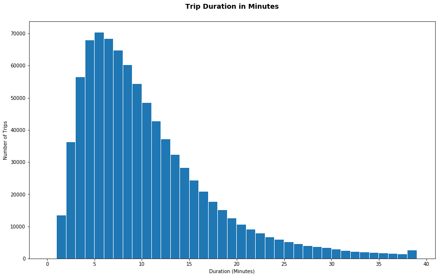

```python
plt.figure(figsize =[15,9]) #Setting the plot size
bin_edges = np.arange(0, 40, 1) #Adjusted to show where the most datapoint lie
ticks = [0, 5, 10, 15, 20, 25, 30, 35, 40,]
labels = [ '{}'.format (val) for val in ticks]

#Plotting
plt.hist(data = rides, x = 'duration_min', bins = bin_edges, rwidth = 0.95)
plt.title('Trip Duration in Minutes', y = 1.04, fontsize = 14, fontweight = 'bold')
plt.xticks(ticks, labels)
plt.xlabel('Duration (Minutes)')
plt.ylabel('Number of Trips');
```

#### Observation

> From the plot above, it can be seen that the average ride is between 3 - 11 minutes.

### Question 2

> What are the busiest hours for taking a ride?

```python
def mybarplot(df, xVar, order):
    '''
    This function plots the counts of observation using bars
    input: rides, variable and order
    '''
    #counts = df['xVar'].value_counts()
    #total = counts.sum()

    #plotting
    plt.figure(figsize=[15,9])#Plot size
    sb.countplot(data = df, x = xVar, order = order, color = sb.color_palette()[0]);

    xVar = xVar.replace("_"," ") #Replacing the _ with space
    plt.ylabel('Number of  Trips')
    plt.xlabel(xVar.title())
    plt.title(f'Ford GoBikes {xVar}'.title(), fontsize = 15, fontweight = 'bold');

    '''
    plt.yticks(size=12);
    locs, labels = plt.xticks(size=14);

    for loc, label in zip(locs, labels):
        count = counts[label.get_text()]
        if count < 25000:
            pct_string = '{:0.1f}%'.format(100*count/total)
            plt.text(loc, count+5000, pct_string, ha = 'center', color = 'black',fontsize = 10, fontweight = 'bold')

        else:
            pct_string = '{:0.1f}%'.format(100*count/total)
            plt.text(loc, count-10000, pct_string, ha = 'center', color = 'white',fontsize = 10, fontweight = 'bold')
    '''
```

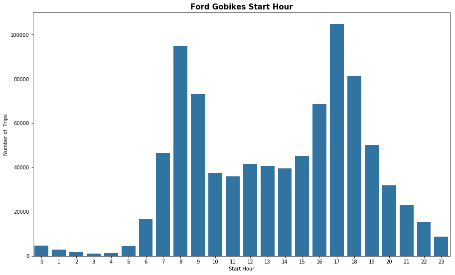

```python
#Changing start_hour column into a string datatype
rides['start_hour'] = rides['start_hour'].astype(str)

#setting the order
startHour_order = np.arange(0 , 24 ).astype(str)

#calling the function
mybarplot(rides, 'start_hour',  order = startHour_order)
```

#### Observation

> The hours are mainly high to start between the morning from 8-9 and from 17-18 in the evening. Those are the rush hours, so it explains the reason for the high volume of rides.

### Question 3

> In what hour are most rides ended?

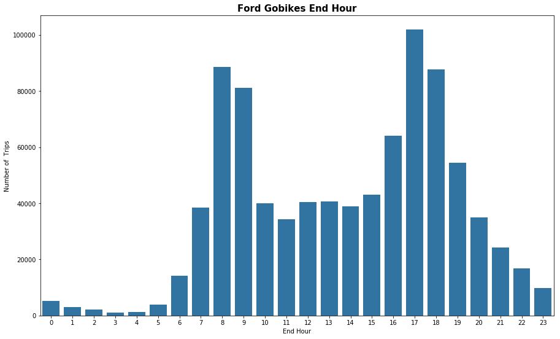

```python
#Changing end_hour column into a string datatype
rides['end_hour'] = rides['end_hour'].astype(str)

#setting the order
endHour_order = np.arange(0 , 24 ).astype(str)

#Calling mybarplot function
mybarplot(rides, 'end_hour',  order = endHour_order)
```

#### Observation

> The hours of end are almost the same with the start.

### Question 4

> What is the average distance travelled for the months under review?

```python
#Checking the description of the distance column
rides['distance_km'].describe()
```

```
count    870174.000000
mean          1.999065
std          59.790095
min           0.000000
25%           0.923877
50%           1.463220
75%           2.281959
max       12798.346860
Name: distance_km, dtype: float64
```

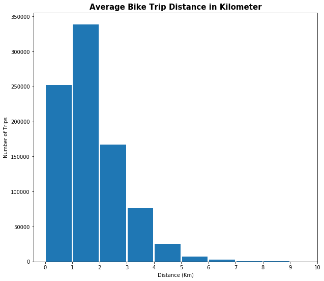

```python
plt.figure(figsize =[10,9])
bin_edges = np.arange(0, 10, 1) #Adjusted to show most datapoints
ticks = [0, 1, 2, 3, 4, 5, 6, 7, 8, 9,10]
labels = [ '{}'.format (val) for val in ticks]

#Plotting
plt.hist(data = rides, x = 'distance_km', bins = bin_edges, rwidth = 0.95)
plt.title('Average Bike Trip Distance in Kilometer', fontsize = 15, fontweight = 'bold')
plt.xticks(ticks, labels)
plt.xlabel('Distance (Km)')
plt.ylabel('Number of Trips');
```

#### Observation

> The average distance of bike trips was under 2 Kilometres. The description of the distance column however showed that there are outliers in the fourth quartile of the data, but it was accounted for in the plotting.

### Question 5

> What day of the week have the most rides?

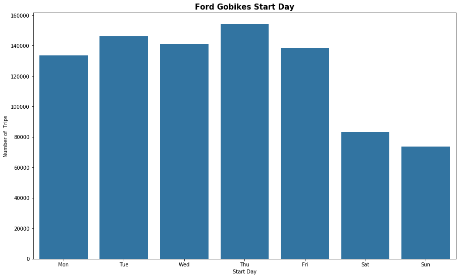

```python
#setting the order
order_of_days=['Mon', 'Tue', 'Wed', 'Thu', 'Fri', 'Sat', 'Sun'] #Ordering the days

#calling the mybarplot function
mybarplot(rides, 'start_day',  order = order_of_days)
```

#### Observation

> Thursday is the most popular day to use the Ford Go Bike sharing system in the Bay Area.

### Question 6

> Of the four months under investigation, which one have the most trips?

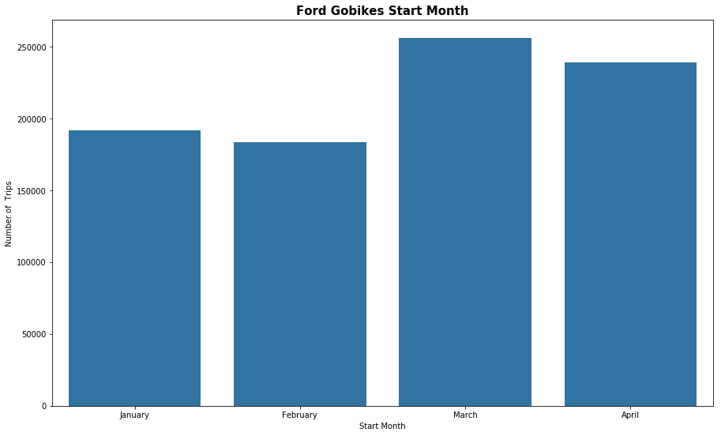

```python
#Setting the order for the months
order_of_month = ['January','February', 'March', 'April'] #Ordering the months

#Calling the function
mybarplot(rides, 'start_month',  order = order_of_month)
```

#### Observation

> March is the most popular month. It records the highest number of usage for the Ford Go Bike sharing system in the Bay Area.

### Discuss the distribution(s) of your variable(s) of interest. Were there any unusual points? Did you need to perform any transformations?

> The distance and duration both have positive symmentry distribution as they are both right skewed. The duration given in seconds was not telling a good tale in my visualization, I converted it to minutes by dividing the records by 60. this gave my analysis a better communication.

### Of the features you investigated, were there any unusual distributions? Did you perform any operations on the data to tidy, adjust, or change the form of the data? If so, why did you do this?

> I spotted in my wrangling stage, the presence of outliers in the fourth quartile of the distance and duration columns. I adjusted the limit of my plots to have a visualization that can better describe the majority of the distribution of my data.

## Bivariate Exploration

### Question 7

> What is the proportion of the customers and subscribers for the months under review?

```python
#Checking the value counts of the user type column
rides.user_type.value_counts()
```

```
Subscriber    754348
Customer      115826
Name: user_type, dtype: int64
```

```python
#Using query method to create proportions for subscriber and customer
customer = rides.query('user_type == "Customer"')['bike_id'].count()
subscriber = rides.query('user_type == "Subscriber"')['bike_id'].count()
customer_prop = customer / rides['bike_id'].count()
subscriber_prop = subscriber / rides['bike_id'].count()
```

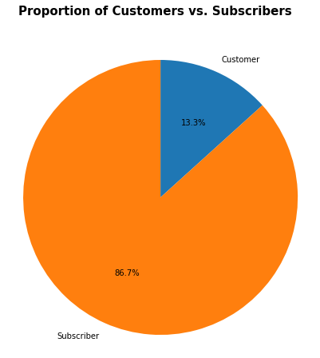

```python
plt.figure(figsize = [7,7]) #Plot size
labels = ['Customer', 'Subscriber']
size = [customer_prop, subscriber_prop]

#Plotting
plt.pie(size, labels = labels, autopct='%1.1f%%', startangle = 90, counterclock = False, textprops={'color':'black'})
plt.axis('square')
plt.suptitle('Proportion of Customers vs. Subscribers',
             fontsize=15, fontweight='bold');
```

#### Observation

> In the first four months of 2019, 86.7% of the user types in the Ford GoBikes sharing platform were Subscribers. 13.3% of the user types in the Ford GoBikes Sharing Platform were Customers.

### Question 8

> How long on the average does each user type ride their bikes for?

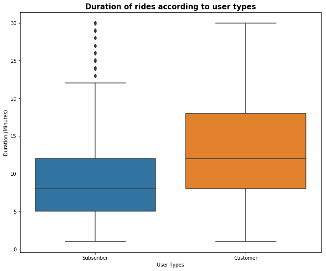

```python
plt.figure(figsize = [11,9]) #Plot size

#Using query method on the data to get records for rides that are 30 minutes and under
#plotting
sb.boxplot(data = rides.query("duration_min <= 30"), x = 'user_type', y = 'duration_min')
plt.title('Duration of rides according to user types', fontsize = 15, fontweight = 'bold')
plt.xlabel('User Types')
plt.ylabel('Duration (Minutes)');
```

### Question 9

> On what days are the users of the bikes most frequent?

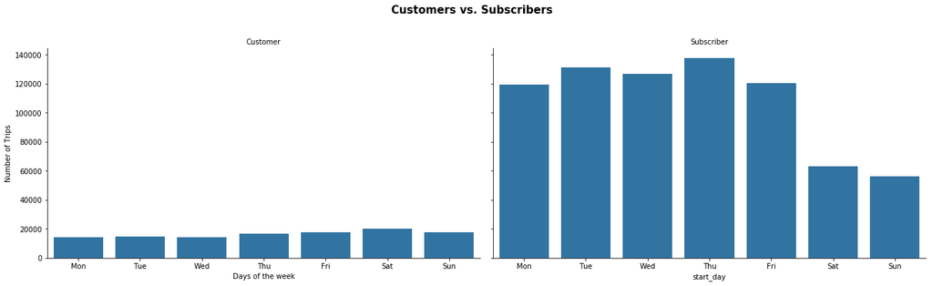

```python
order_of_days=['Mon', 'Tue', 'Wed', 'Thu', 'Fri', 'Sat', 'Sun'] #Ordering the days

#plotting
g = sb.FacetGrid(data=rides,col='user_type', col_wrap = 2, aspect=1.8, size = 5, sharey=True,)
g.map(sb.countplot, 'start_day', order = order_of_days);
for i in range(2):
    g.axes[i].set_xlabel('Days of the week')
    g.set_titles("{col_name}")
    g.axes[i].set_ylabel('Number of Trips')
    g.fig.suptitle('Customers vs. Subscribers', y= 1.1, fontsize=15, fontweight='bold')
    plt.show();
```

#### Observation

> The customers usage is quite low and consistant staying under 20,000 bike trips during the week. While Subscribers frequently used the the Ford GoBikes Sharing platform for about 120,000 - 130,000 trips during Monday - Friday with a significant drop through to Saturday and Sunday.

### Question 10

> According to the user type, what are the top 10 go to stations for taking a ride?

```python
#Getting the counts of subcribers and customers by querying method
subcribers = rides.query('user_type == "Subscriber"').start_station_name.value_counts()
customers = rides.query('user_type == "Customer"').start_station_name.value_counts()

freq_station = rides.start_station_name.value_counts()

#Selecting the top 10 stations
y = freq_station.values[0:10]
x = freq_station.index[0:10]

#Selecting the top ten subcribers
x_sub = subcribers.index[0:10]
y_sub = subcribers.values[0:10]

#selecting the top ten customers
x_cus = customers.index[0:10]
y_cus = customers.values[0:10]
```

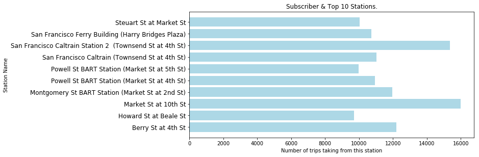

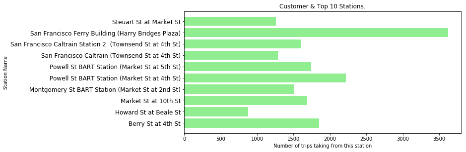

```python
plt.figure(figsize = [10, 10]) #Plot size

#plotting
plt.subplot(2, 1, 1)
plt.barh(x,subcribers[x],color='lightblue')
plt.yticks(fontsize=12)
plt.title('Subscriber & Top 10 Stations.')
plt.xlabel('Number of trips taking from this station')
plt.ylabel('Station Name');

plt.figure(figsize = [10, 10])
plt.subplot(2, 1, 2)
plt.barh(x,customers[x],color='lightgreen')
plt.yticks(fontsize=12)
plt.title('Customer & Top 10 Stations.')
plt.xlabel('Number of trips taking from this station')
plt.ylabel('Station Name');
```

### Question 11

> What is the higest average distance travelled for the months under review according to the user types?

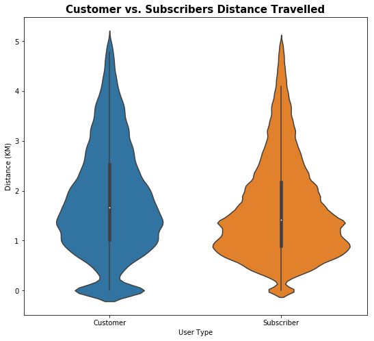

```python
plt.figure(figsize = [9, 8]) #Specying the plot size

#Plotting
sb.violinplot(data = rides.query('distance_km < 5'), x = 'user_type', y = 'distance_km')
plt.title('Customer vs. Subscribers Distance Travelled', fontsize=15, fontweight='bold')
plt.xlabel('User Type')
plt.ylabel('Distance (KM)')
plt.show()
```

#### Observation

> The Distance in Kilometters by User Type plot highlights that Customers normally have longer trip distance. Customers normally ride between 1 and 2.5 kilometres. Subscriber trips are normally shorter and last anywhere between 0.8-2.1 kilometres.

### Question 12

> How did the months performed in terms of the duration of the rides?

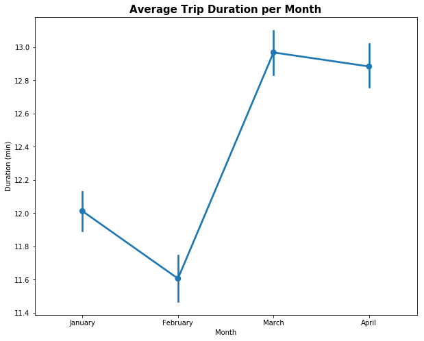

```python
plt.figure(figsize = [10, 8]) #Plot size

month_order = ['January', 'February', 'March', 'April'] #ordering the months

#Plotting
sb.pointplot(data = rides, x = 'start_month', y = 'duration_min', order = month_order)
plt.title('Average Trip Duration per Month', fontsize=15, fontweight='bold')
plt.xlabel('Month')
plt.ylabel('Duration (min)');
```

#### Observation

> The average trip duration has been fluctuating by the month. There was a decrease from January to February, a very significant increase for March and a decline again in April.

### Did you observe any interesting relationships between the other features (not the main feature(s) of interest)?

> The start month and duration of trips have a relationship that can best be described as a wave. It goes up, comes down, goes up again and comes back down. I was expecting a steady increase or decrease, but it was just flunctuating.

## Multivariate Exploration

> Create plots of three or more variables to investigate your data even further. Make sure that your investigations are justified, and follow from your work in the previous sections.

### Question 13

> How many minutes did each user type ride their bikes for, per month?

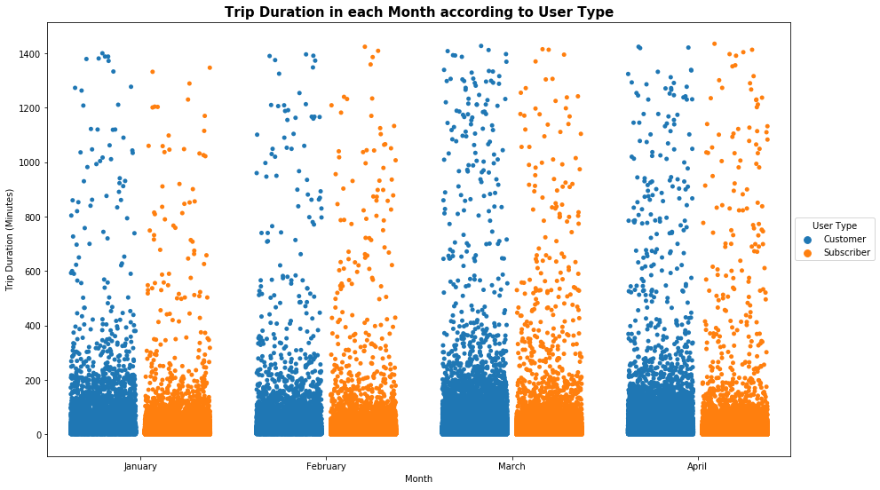

```python
plt.figure(figsize = [15,9]) #Plot size


month_order = ['January', 'February', 'March', 'April'] #Ordering the month

#plotting
sb.stripplot(data = rides, x = 'start_month', y = 'duration_min', hue = 'user_type',jitter = 0.35, dodge = True, order = month_order)
plt.legend(loc = 'center left', bbox_to_anchor = (1, 0.5), title = 'User Type')
plt.title('Trip Duration in each Month according to User Type', fontsize = 15, fontweight = 'bold')
plt.xlabel('Month')
plt.ylabel('Trip Duration (Minutes)');
```

#### Observation

> When viewed by month and without setting limits, the plot shows that some customers had similar trip durations with subscribers for February to April. The trip duration for customers in January are slightly higher than subscribers'.

### Question 14

> What is the daily trip duration for each user type?

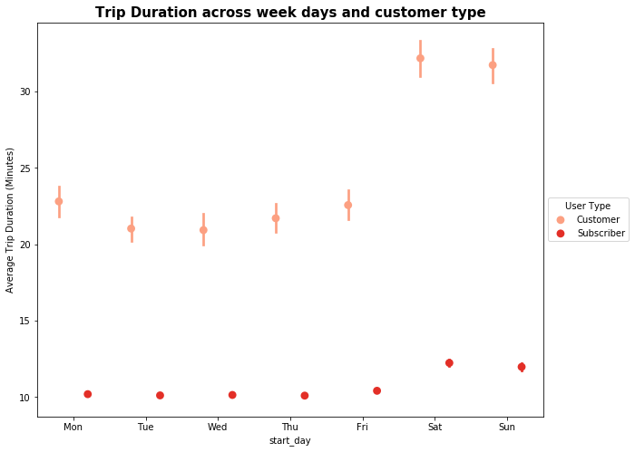

```python
fig = plt.figure(figsize = [10,8]) #Plot size

order_of_days=['Mon', 'Tue', 'Wed', 'Thu', 'Fri', 'Sat', 'Sun'] #Ordering the days

#Plotting
ax = sb.pointplot(data = rides, x ='start_day', y = 'duration_min', hue = 'user_type',
           palette = 'Reds', linestyles = '', dodge = 0.4, order = order_of_days)
plt.title('Trip Duration across week days and customer type', fontsize = 15, fontweight = 'bold')
plt.ylabel('Average Trip Duration (Minutes)')
plt.legend(loc = 'center left', bbox_to_anchor = (1, 0.5), title = 'User Type')
ax.set_yticklabels([],minor = True)
plt.show();
```

### Question 15

> What is the relationship between User type, start hour and start days?

```python
#Setting the order for hours and day
startHour_order = np.arange(0 , 24 ).astype(str)
order_of_days=['Mon', 'Tue', 'Wed', 'Thu', 'Fri', 'Sat', 'Sun']
```

```python
#Grouping the subscribers by day and hour count
subscribers = rides.query('user_type == "Subscriber"').groupby(['start_day','start_hour']).size()

#moving the day to the column index
subscribers = rides.query('user_type == "Subscriber"').groupby(['start_day','start_hour']).size().unstack('start_day').head()

#Reindexing the row index and selecting the columns in the correct order
subscribers = rides.query('user_type == "Subscriber"').groupby(['start_day','start_hour']).size().unstack('start_day').reindex(startHour_order)[order_of_days]
subscribers
```

| start_day start_hour | Mon | Tue | Wed | Thu | Fri | Sat | Sun |
| --- | --- | --- | --- | --- | --- | --- | --- |
| 0 | 365 | 442 | 383 | 510 | 613 | 926 | 774 |
| 1 | 204 | 258 | 210 | 218 | 368 | 604 | 501 |
| 2 | 152 | 164 | 125 | 171 | 186 | 342 | 362 |
| 3 | 99 | 111 | 77 | 102 | 137 | 150 | 168 |
| 4 | 170 | 183 | 138 | 192 | 205 | 105 | 105 |
| 5 | 729 | 864 | 716 | 794 | 663 | 170 | 169 |
| 6 | 2834 | 3257 | 2923 | 3115 | 2630 | 414 | 292 |
| 7 | 7954 | 8914 | 7968 | 8865 | 7600 | 877 | 653 |
| 8 | 16008 | 17584 | 16634 | 17480 | 15504 | 1875 | 1333 |
| 9 | 11422 | 12872 | 11710 | 12713 | 11960 | 3161 | 2390 |
| 10 | 4635 | 4764 | 4680 | 5435 | 5234 | 4070 | 3411 |
| 11 | 4065 | 3881 | 3744 | 4406 | 4576 | 4885 | 4098 |
| 12 | 4633 | 4729 | 4461 | 5143 | 5141 | 5190 | 4644 |
| 13 | 4134 | 4363 | 4379 | 4780 | 4759 | 5296 | 4816 |
| 14 | 3886 | 4222 | 3995 | 4492 | 4385 | 5188 | 4903 |
| 15 | 4669 | 5241 | 5109 | 5595 | 5515 | 5075 | 4910 |
| 16 | 8724 | 9675 | 9734 | 10133 | 9911 | 4905 | 4910 |
| 17 | 15579 | 17309 | 17057 | 17640 | 14504 | 4929 | 4516 |
| 18 | 12025 | 13350 | 13064 | 14076 | 10645 | 4226 | 3903 |
| 19 | 7242 | 7806 | 7957 | 8310 | 6142 | 3370 | 3154 |
| 20 | 4455 | 5026 | 4840 | 5544 | 3548 | 2419 | 2379 |
| 21 | 2757 | 3363 | 3604 | 3932 | 2696 | 2075 | 1759 |
| 22 | 1707 | 1972 | 2189 | 2493 | 2217 | 1491 | 1181 |
| 23 | 860 | 980 | 1014 | 1313 | 1427 | 1201 | 706 |

```python
#Grouping the subscribers by day and hour count
customers = rides.query('user_type == "Customer"').groupby(['start_day','start_hour']).size()

#moving the day to the column index
customers = rides.query('user_type == "Customer"').groupby(['start_day','start_hour']).size().unstack('start_day').head()

#Reindexing the row index and selecting the columns in the correct order
customers = rides.query('user_type == "Customer"').groupby(['start_day','start_hour']).size().unstack('start_day').reindex(startHour_order)[order_of_days]
customers
```

| start_day start_hour | Mon | Tue | Wed | Thu | Fri | Sat | Sun |
| --- | --- | --- | --- | --- | --- | --- | --- |
| 0 | 61 | 85 | 54 | 76 | 107 | 168 | 189 |
| 1 | 36 | 60 | 35 | 39 | 53 | 136 | 147 |
| 2 | 8 | 30 | 8 | 14 | 50 | 79 | 124 |
| 3 | 2 | 13 | 4 | 19 | 15 | 25 | 51 |
| 4 | 20 | 13 | 18 | 17 | 17 | 27 | 31 |
| 5 | 55 | 57 | 67 | 79 | 70 | 30 | 37 |
| 6 | 223 | 222 | 211 | 218 | 194 | 34 | 35 |
| 7 | 646 | 670 | 605 | 698 | 673 | 129 | 132 |
| 8 | 1423 | 1564 | 1487 | 1527 | 1608 | 337 | 332 |
| 9 | 1027 | 1091 | 955 | 1233 | 1317 | 642 | 577 |
| 10 | 641 | 530 | 526 | 663 | 755 | 1164 | 1005 |
| 11 | 746 | 582 | 561 | 646 | 852 | 1543 | 1345 |
| 12 | 799 | 704 | 668 | 785 | 934 | 1847 | 1763 |
| 13 | 776 | 776 | 663 | 792 | 963 | 2155 | 1993 |
| 14 | 842 | 766 | 724 | 809 | 998 | 2302 | 1962 |
| 15 | 887 | 961 | 884 | 1008 | 1213 | 2189 | 1983 |
| 16 | 1207 | 1151 | 1244 | 1359 | 1623 | 2014 | 1829 |
| 17 | 1748 | 1993 | 2071 | 2242 | 2070 | 1717 | 1349 |
| 18 | 1262 | 1542 | 1516 | 1836 | 1559 | 1277 | 1028 |
| 19 | 749 | 880 | 867 | 993 | 978 | 846 | 679 |
| 20 | 416 | 502 | 526 | 611 | 578 | 593 | 390 |
| 21 | 304 | 370 | 362 | 437 | 505 | 425 | 261 |
| 22 | 212 | 241 | 275 | 339 | 361 | 375 | 201 |
| 23 | 90 | 107 | 149 | 171 | 282 | 270 | 103 |

[figure not shown]

```python
plt.figure(figsize = [20, 20]) # larger figure size for subplots


plt.subplot(2,2,1)
sb.heatmap(subscribers)
plt.title('Subscriber', fontsize = 15, fontweight = 'bold')
plt.ylabel('Days')
plt.xlabel('Hour of the trip');

plt.subplot(2,2,2)
sb.heatmap(customers)
plt.title('Customer', fontsize = 15, fontweight = 'bold')
plt.ylabel('Days')
plt.xlabel('Hour of the trip');
```

#### Observation

> From the heat map above, Customers who use the Ford Gobikes sharing system mainly on the weekends. While, Subscriber normally ride bikes during the weekday from Monday through to Friday, around 8-9 and 16-18. In the weekends, there is a significant drop in the number of rented bikes.

### Talk about some of the relationships you observed in this part of the investigation. Were there features that strengthened each other in terms of looking at your feature(s) of interest?

> 1. Trip duration by the day was steady around 10 minutes on weekdays for subscribers and slightly higher on weekends. But it is different for customers, they spend more time than the subscribers during the weekdays and spend the most time on weekends.
> 2. The heatmap showed that customers use the bike the most on weekends, while weekdays are when the subscribers use the bikes the most.